# NetID User Manual

Li Chen, Ran Liu, Tianyu Zhou

2023/8/28

# 1 Introduction

Liquid chromatography–high-resolution mass spectrometry (LC-MS)-based metabolomics aims to identify and quantify all metabolites, but most LC-MS peaks remain unidentified. Here we present a global network optimization approach, NetID, to annotate untargeted LC-MS metabolomics data. The approach aims to generate, for all experimentally observed ion peaks, annotations that match the measured masses, retention times and (when available) tandem mass spectrometry fragmentation patterns. Peaks are connected based on mass differences reflecting adduction, fragmentation, isotopes, or feasible biochemical transformations. Global optimization generates a single network linking most observed ion peaks, enhances peak assignment accuracy, and produces chemically informative peak–peak relationships, including for peaks lacking tandem mass spectrometry spectra. Thus, NetID applies existing metabolomic knowledge and global optimization to substantially improve annotation coverage and accuracy in untargeted metabolomics datasets, facilitating metabolite discovery.

NetID requires: (1) data file (in .mzXML format), (2) a peak table (in .csv format), (3) a reference compound library (in .rds format), (4) a transformation table (in .csv format), for which we assembled a list of 25 biochemical atom differences and 59 abiotic atom differences. NetID optionally use (5) a list of known metabolites’ retention time, for which we provide our in-house retention time list for demonstration and (6) .mgf file containing MS2 information and (7) MS2 reference library (in .rds format). More details in section 3.1.

In the 2023 August version, we implemented the following updates:  
(1) Include both orbitrap and TOF demo data;  
(2) Handle data-dependent MS2 data;  
(3) Incorporate FastNetID codes proposed in OmicsNet<sup>1</sup>, which uses C language to accelerate calculations in NetID;  
(4) Provide a detailed peak picking workflow using MZmine3<sup>2</sup> and EVA<sup>3</sup>;  
(5) Merge two compound libraries HMDB<sup>4</sup> and PubChemLite<sup>5-6</sup>;  
(6) Restructure the workflow to remove unstable functions and simplify the parameter settings.

**Citation**: Chen, L., Lu, W., Wang, L. et al. Metabolite discovery through global annotation of untargeted metabolomics data. Nat Methods 18, 1377–1385 (2021). https://doi.org/10.1038/s41592-021-01303-3  
**Git-hub**: https://github.com/LiChenPU/NetID

**Reference**:

1. Zhou, G., Pang, Z., Lu, Y., Ewald, J. & Xia, J. OmicsNet 2.0: A web-based platform for multi-omics integration and network visual analytics. Nucleic Acids Research gkac376 (2022).
2. Schmid, R. et al. Integrative analysis of multimodal mass spectrometry data in MZmine 3. Nat Biotechnol 41, 447–449 (2023).
3. Guo, J. et al. EVA: Evaluation of Metabolic Feature Fidelity Using a Deep Learning Model Trained With Over 25000 Extracted Ion Chromatograms. Anal. Chem. 93, 12181–12186 (2021).
4. Wishart, D. S. et al. HMDB 4.0: The human metabolome database for 2018. Nucleic Acids Research 46, D608–D617 (2018).
5. Kim, S. et al. PubChem 2019 update: Improved access to chemical data. Nucleic Acids Research 47, D1102–D1109 (2019).
6. Bolton, E. & Schymanski, E. PubChemLite tier0 and tier1. Zenodo https://doi.org/10.5281/zenodo.3611238 (2020).

# 2 Environment Setup

This section provides step-by-step instructions to set up the environment to run NetID algorithm in a local computer.

## 2.1 Software installation

Install R, Rstudio, Rtools43, ILOG CPLEX Optimization Studio (CPLEX), Git, and ProteoWizard, preferably at default locations. You may need to add these softwares to `PATH`.

**R** (version 4.3.1 tested): https://www.r-project.org/  
**RStudio**: https://rstudio.com/products/rstudio/download  
**Rtools43**: https://cran.r-project.org  
**CPLEX** (version 12.10 tested): https://www.ibm.com/academic/technology/data-science  
**ProteoWizard**: http://www.proteowizard.org/download.html  
**Git**: https://git-scm.com/downloads

## 2.2 Code download

### 2.2.1 Via Github

Go to website https://github.com/LiChenPU/NetID, hit the green **code** button, select download zip, and unzip files.

### 2.2.2 Via Git

In Rstudio, go to `File` $\rightarrow$ `New project` $\rightarrow$ `Version control` $\rightarrow$ `Git`, enter https://github.com/LiChenPU/NetID.git for `URL`, select a subdirectory, and create project.

You should be able to see all files in place under your selected subdirectory. Use the `pull` option in Git to check for the latest updates.

In the downloaded NetID file, the `dependence` folder stores all reference files, the `code` folder stores codes needed for NetID, the `data` folder stores the data to be processed.

## 2.3 Demo data download

Demo data can be downloaded at:

1. URL: https://drive.google.com/drive/folders/1oOpnu8dlV1Ra-fxJBX671eJaRnCJ_QNZ?usp=sharing.
2. URL: https://pan.baidu.com/s/1wcpNOqI9M3IYHQ_xGulSKA, Password: `drjr`.

The download demo data is saved in the `data` folder. For example, replace the `./data/QTOF_6600_demo/pos/raw_data` folder with the downloaded raw_data folder.

## 2.4 Package dependency installation

### 2.4.1 Install common packages

1. Open the R script `NetID_packages.R` in `get started` folder.
2. Run all lines.

### 2.4.2 Install cplexAPI

1. Go to website https://cran.r-project.org/src/contrib/Archive/cplexAPI/, look for Package source, and download cplexAPI_1.4.0.tar.gz.
2. The package, **cplexAPI**, requires additional installation steps.
3. Unzip the folder `cplexAPI` to the `desktop`,open subfolder `src`,modify the file `Makevars.win`.
   - Replace `\` in the `Makevars.win` file into `/` in order for R to recognize the path. `-I"${CPLEX_STUDIO_DIR}\cplex\include"` should be replaced with path such as:  
     `-I"C:/Program Files/IBM/ILOG/CPLEX_Studio1210/cplex/include"`
   - The `-L"${CPLEX_STUDIO_LIB}"` should be replaced with path such as `-L"C:/Program Files/IBM/ILOG/CPLEX_Studio1210/cplex/bin/x64_win64"`
4. In command line, run line below to build package, change `${Username}` to actual name. `R CMD build --no-build-vignettes --no-manual --md5 "C:\Users\${Username}\Desktop\cplexAPI"`
5. In command line, run line below to install package.  
   `R CMD INSTALL --build --no-multiarch .\cplexAPI_1.4.0.tar.gz`
6. If you see **DONE (cplexAPI)**, then the package installation is successful.
   - **Note**: if error occurs relating to `__declspec(dllimport deprecated)`, you need to go to `C:\Program Files\IBM\ILOG\CPLEX_Studio1210\cplex\include\ilcplex` (or your own installation folder), open the file `cpxconst.h`, go to the line indicated in the error message or search for `__declspec(dllimport deprecated)`, add `_` in between, make it to `__declspec(dllimport_deprecated)`. Save file and repeat *step 4*.

# 3 Using NetID

## 3.1 Data requirment

### 3.1.1 MS data

The MS data should be placed in the raw_data folder of the analyzed folder (such as ./data/QTOF_6600_demo/neg/raw_data) as mzXML files. **mzXML** is a file format commonly used for storing mass spectrometry data, particularly from LC-MS experiments. mzXML format contains information about mass spectra, including the m/z (mass-to-charge ratio) values, ion intensities, retention times associated with the experiment.

**Convert raw data to mzXML**  
Use software ProteoWizard to convert LC-MS data files (.raw or .wiff) into mzXML format.

- Click the `Browse` button to select files you want to process, then click the `add` button.
- Click `Output format` button to select the file format to be generated.
- Within the filter option, select `Peak Picking`, then set `MS level` to 1-2, and click the `add` button.
- Click the `start` button.

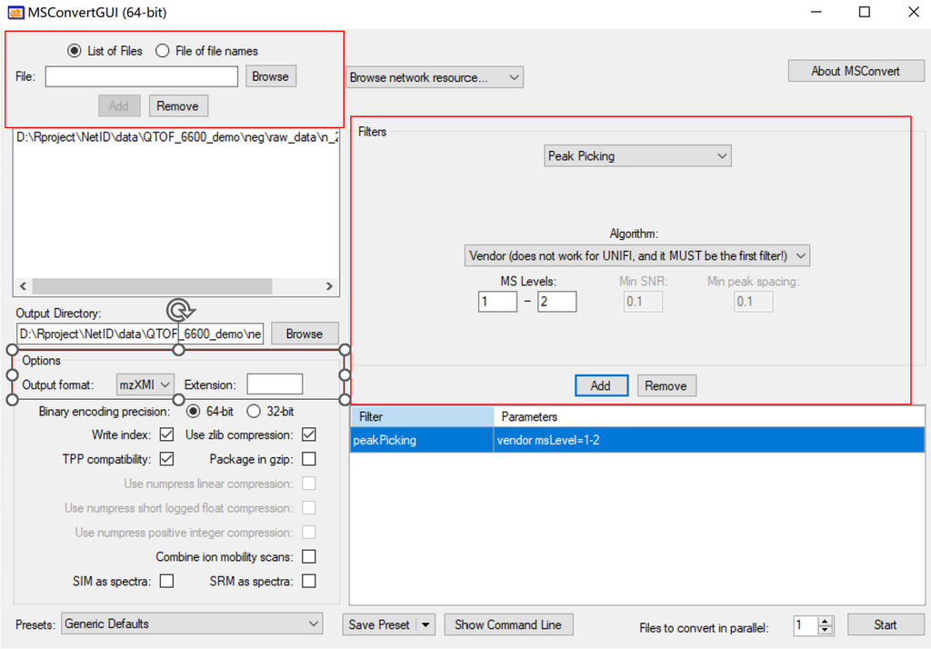

### 3.1.2 Peak table

```r
read.csv("../NetID/get started/UserGuideMD/peak_table.csv")[1:3,]
```

```
##     id      mz    rt rtmin rtmax n_293T_2 mean_inten
## 1 1531 71.0140  9.49  9.05  9.62    12000      12000
## 2 2426 71.0141 11.66 11.54 11.79     1800       1800
## 3 1664 72.0091  9.80  9.73  9.87     1200       1200
```

You can use any software to obtain your own peak table, as long as it is converted to the format above. If rtmin and rtmax is not known, use rt ± a certain fixed number (e.g. ± 0.5). Note that all isotopes, adducts, fragments should not be removed in the peak table as they are important information for NetID global optimization.  
We provide our workflow for obtaining the peak table in section 5.

### 3.1.3 MS2 data

The MS2 data files should be placed in the raw_data folder of the analyzed folder (such as ./data/QTOF_6600_demo/neg/raw_data/MS2_Data) as mgf files. A data-dependent acquisition file is used to obtain the mgf file using **ProteoWizard**.  
Click the `Output format` button and select `mgf` format.

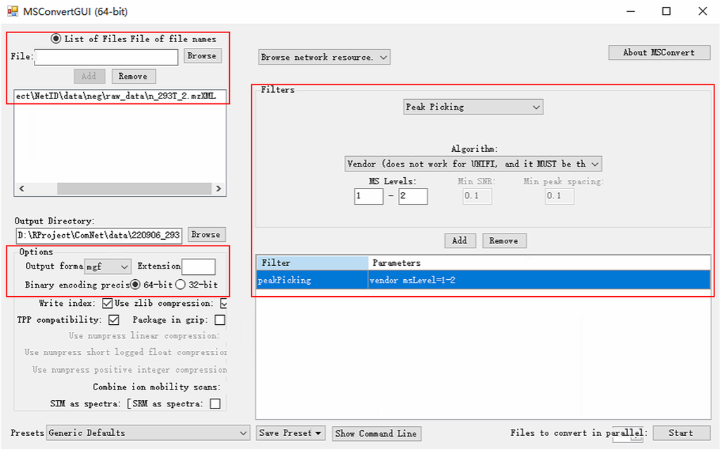

### 3.1.4 Reference compound library

The compound library exists in the `dependence` folder as a rds file. It records the compound information, such as accession, name, SMILES, status, formula, mass, rdbe, etc. The information is extracted from and merged with two compound libraries: HMDB and PubChemLite.

```r
readRDS("../NetID/dependence/hmdb_pubchemlite_merge_result_simple.rds")[1:3, -c(9,10)]
```

```
##     accession               name                      SMILES   formula     mass
## 1 HMDB0000001  1-Methylhistidine CN1C=NC(C[C@H](N)C(O)=O)=C1 C7H11N3O2 169.0851
## 2 HMDB0000002 1,3-Diaminopropane                       NCCCN   C3H10N2  74.0844
## 3 HMDB0000005 2-Ketobutyric acid               CCC(=O)C(O)=O    C4H6O3 102.0317
##   rdbe PubMed_Count     status     FirstBlock   category
## 1    4           94 quantified BRMWTNUJHUMWMS Metabolite
## 2    0          575 quantified XFNJVJPLKCPIBV Metabolite
## 3    2          328 quantified TYEYBOSBBBHJIV Metabolite
```

### 3.1.5 Known library

The known library exists in the `dependence` folder as a csv file. It records the retention time information of metabolites. We provide our in-house RT table for demo.

```r
readRDS("../NetID/get started/UserGuideMD/RT_library.rds")
```

```
##     accession                  name                                   SMILES
## 1 HMDB0000001     1-Methylhistidine              CN1C=NC(C[C@H](N)C(O)=O)=C1
## 2 HMDB0000005    2-Ketobutyric acid                            CCC(=O)C(O)=O
## 3 HMDB0000008 2-Hydroxybutyric acid                         CC[C@H](O)C(O)=O
## 4 HMDB0000011 3-Hydroxybutyric acid                        C[C@@H](O)CC(O)=O
## 5 HMDB0000012          Deoxyuridine OC[C@H]1O[C@H](C[C@@H]1O)N1C=CC(=O)NC1=O
##     formula     mass rdbe     status Hilicon
## 1 C7H11N3O2 169.0851    4 quantified   8.658
## 2    C4H6O3 102.0317    2 quantified   4.159
## 3    C4H8O3 104.0473    1 quantified   5.698
## 4    C4H8O3 104.0473    1 quantified   7.336
## 5 C9H12N2O5 228.0746    5 quantified   3.596
```

### 3.1.6 MS2 spectral library

The MS2 spectral library exists in the `dependence` folder as a rds file. It records the reference MS2 spectra. We download MS2 data from HMDB and convert it into the format we defined.

```r
readRDS("../NetID/get started/UserGuideMD/MS2_library.rds")[1]
```

```
## [[1]]
## [[1]]$spectrum
##         mz intensity formula
## 1 101.0244         1  C4H6O3
##
## [[1]]$notes
## character(0)
##
## [[1]]$formula
## [1] "C4H6O3"
##
## [[1]]$external_id
## [1] "HMDB0000005"
##
## [[1]]$SMILES
## [1] "CCC(=O)C(O)=O"
##
## [[1]]$precursor_mz
## [1] 101.0244
##
## [[1]]$polarity
## [1] "negative"
##
## [[1]]$instrument_type
## [1] "LC-ESI-QTOF (UPLC Q-Tof Premier, Waters)"
##
## [[1]]$collision_energy_level
## character(0)
##
## [[1]]$collision_energy_voltage
## character(0)
##
## [[1]]$adduct
## [1] "M-H"
##
## [[1]]$data_source
## [1] "Experimental spectra from HMDB"
```

### 3.1.7 Transformation table

The transformation table exists in the `dependence` folder `empirical_rules.csv`. It records the connection types (or edges) used in NetID, such as CH2 as a biotransformation connection, or Na-H as an adduct connection.

```r
read.csv("../NetID/dependence/empirical_rules.csv")[c(1,27,43,86,88),]
```

```
##             category  name   formula       mass direction rdbe        note
## 1       Biotransform  O-HN  O1N-1H-1  0.9840156         0  0.0 Deamination
## 27 Natural_abundance [15]N [15]N1N-1  0.9970350         1  0.0
## 43            Adduct  Na-H    H-1Na1 21.9819446         1  0.0
## 86          Fragment   H2O      H2O1 18.0105647        -1 -1.0
## 88           Radical     H        H1  1.0078250        -1 -0.5
```

## 3.2 Input in NetID

Check if all files mentioned above are ready for running NetID.

```
       MS_type = 'QTOF' # QTOF, Orbitrap
       instrument_parameter_type = "Default"  # Custom
       instrument_parameter_custom = data.frame(ppm = 10e-6,
                                                ms1_ms2_match_ppm = 20e-6,
                                                propagation_ppm = 10e-6,
                                                record_ppm = 10e-6,
                                                edge_expand_inten_cutoff = 1e3,
                                                score_mz_ppm_error_rate = -0.125)
```

## 3.3 Main steps and successful result

### 3.3.1 Set NodeSet and EdgeSet

```
Setting up NodeSet and EdgeSet...
[1] "3453 negative nodes"
           Adduct      Biotransform          Fragment Natural_abundance           Radical
             6572              8274               661              8617               591
```

### 3.3.2 EdgeSet_expand

```
Setting up LibrarySet and StructureSet...
start EdgeSet_expand...
[1] "oligomer_multicharge 278"
[1] "experiment_MS2_fragment 4849"
[1] "library_MS2_fragment 7"
Candidate formula pool propagation and scoring...
[1] "Step 1 elapsed="
Time difference of 5.939358 secs
[1] "Step 2 elapsed="
Time difference of 15.9693 secs
[1] "Step 0.01 elapsed="
Time difference of 27.72133 secs
[1] "Step 0.02 elapsed="
Time difference of 42.09879 secs
[1] "Step 0.03 elapsed="
Time difference of 1.11554 mins
[1] "Step 1.01 elapsed="
Time difference of 1.398908 mins
[1] "Step 1.02 elapsed="
Time difference of 1.706977 mins
[1] "Step 1.03 elapsed="
Time difference of 2.239343 mins
```

### 3.3.3 CplexSet and ilp_nodes and ilp_edge

```
setting up CplexSet...
[1] "Finish CplexSet initialization"
[1] "Finish CplexSet scoring"
[1] "Complexity is 264379 variables and 368739 constraints."
     nc      nr CPX_MAX     obj     rhs   sense     beg     cnt     ind     val      lb      ub   ctype
      1       1       1  264379  368739  368739  264379  264379  836463  836463  264379  264379  264379
    mat
      6
```

### 3.3.4 Run optimization.

In the console, error message should not occur. If optimization step is successful, you will see messages in the following format.

```
Run optimization...
[1] "Optimization ended successfull - optimal  - OBJ_value = 1989.44"
41.87 sec elapsed
path annotation...
Time difference of 7.028952 mins
NetID total run time:Time difference of 12.96994 mins
```

## 3.4 Customized settings

### 3.4.1 Customized known library

In the `dependence` folder, open the `known_library.csv` file. Add or remove metabolites in the known library file as you wish. For RT information, add column to record retention time. Multiple RT lists can be stored by adding additional columns. Empty retention time is allowed for a entry.

In `NetID_run_script.R`, set `LC_method` to the column name to input RT information in NetID.

### 3.4.2 Customized MS2 spectral library

A limited number of MS2 spectra are included in the demo. You can adapt your own MS2 library to the existing format.

### 3.4.4 Score Setting

See Supplementary Note 2 of NetID paper for explanation

# 4 NetID Visualization

This section provides instruction to visualize and explore **NetID** output results in either **Cytoscape** software or interactive **Shiny R app**. After running **NetID** algorithm, it will export one `.R` and two `.csv`files (`cyto_node.csv` and `cyto_edges.csv`), storing the nodes and edges of the output network.

## 4.1 Shiny App

This part provides instruction to visualize and explore **NetID** output results in the interactive **Shiny R app**. A 21-inch or larger screen is recommended for best visualization.

### 4.1.1 Runing Shiny App

1. Open `code` folder $\rightarrow$ `R_shiny_App.R`.
2. In the `# Read in files #### section`, set datapath as `../NetID/data/QTOF_6600_demo/neg/`
3. Keep all other parameters as default, and run all lines.
4. A Shiny app will pop up.

### 4.1.2 Searching peaks of interest

1. On the left panel, you can enter a m/z or a formula to search your peak of interest. For example, 678.4405 or C35H67O10P1 will automatically update the data table on the right. Enter 0 to restore full list for the data table.
2. Change ionization and ppm window to adjust calculated m/z.
3. On the right, you can explore the peak list in an interactive data table, including global text search on top right, specifying ranges for numeric column or searching text within character columns, ranking each column etc.

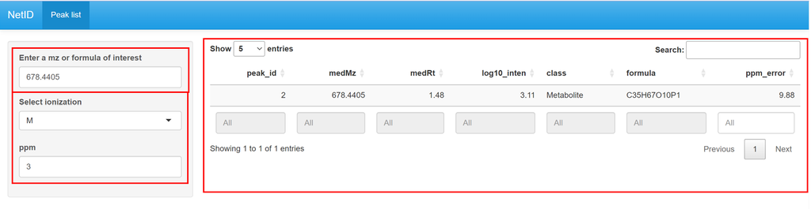

### 4.1.3 Network Visualization

1. Peak ID, formula and class determines the center node for the network graph. Peak ID will be automatically updated by the first line in the data table if a m/z or formula is given. Alternatively, you can manually enter Peak ID.
2. The degree parameter controls how far the network expands from the center node. Degree 1 means only nodes directly connected to the center node will be shown and degree 2 means nodes connected to degree 1 will be shown, etc.
3. Biochemical graph shows biochemical connections. Abiotic graph shows abiotic connections. Node labels and Edge labels determines if the graph show node or edge labels. Optimized only determines whether to show only the optimal annotations or all possible annotations in the network.
4. When setting parameters, hit plot to see the network graph.

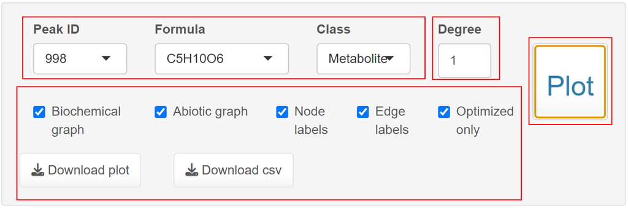

5. A sample network graph is shown below (a different center node may give less complicated graph). You may edit the nodes or edges (top left), move figures with the arrow buttons (bottom left), and zoom in/out or center figure (bottom right).

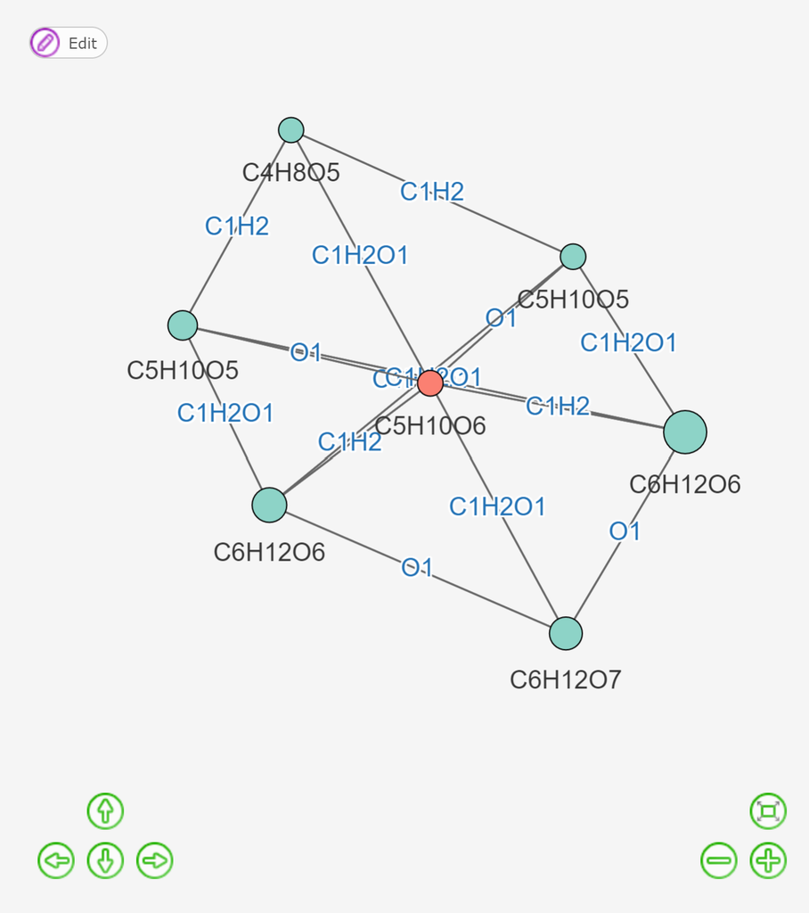

6. You can use the “Download plot” button to download a html webpage to visualize the network graph independent of the Shiny app, and the “Download csv” button to download the information of the nodes in the network. The download buttons will appear after hitting the plot button. Note: edits within the Shiny app will not go into the html file.

### 4.1.4 Possible structures exploration

A figure + data table is provided to explore structures of the selected node in the network graph.

1. The figure shows the chemical structure of the annotated metabolites. If the node is annotated as a putative metabolite, only the known parts of the putative metabolite will be shown.  
   Scroll left or right, or select the entry number, to visualize different annotations. Right click and select to save image.
2. In the data table, class has 3 possible entries: Metabolite if it is documented in database such as HMDB library; Putative metabolite if it is transformed from a metabolite through a biotransformation edge; and Artifact if it is transformed by an abiotic edge.  
   Use the download button to download the data table

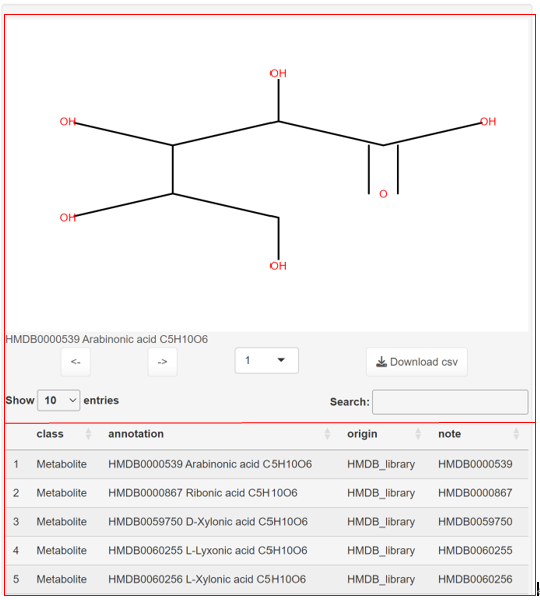

## 4.2 Cytoscape

1. install **Cytoscape** (https://cytoscape.org/what_is_cytoscape.html) Download **Cytoscape** (https://cytoscape.org/download.html) and follow installation instruction to install onto your computer.
2. Load the example **NetID** output into **Cytoscape**
   - Run **Cytoscape**, click `import network from file system`, and load `cyto_edges.csv`, set `edge_id` column as the `key`.
   - Click `import table from file`, load `cyto_node.csv`, set `node_id` column as the `key`, and the rest columns as `node attribute`.
   - Select `subnetwork`, set `styles`, and explore the network with various functionalities inside **Cytoscape**.
3. Explore in Cytoscape  
   http://manual.cytoscape.org/en/stable/index.html provides all you need to know about exploring in **Cytoscape**.
4. Export  
   The network as well as the curated subnetworks can be exported for future analysis or sharing with others.

# 5 Peak picking workflow

NetID is an untargeted metabolomics annotation algorithm. There are many existing software/workflows for peak picking and most metabolomics labs/facilities have their own preference.  
We provide a workflow that works resonably well in our lab. We use data in `./data/QTOF_6600_demo/neg/raw_data` for demo. You may compare different workflows and pick your own.

## 5.1 Peak picking with mzmine3

**MZmine3**: https://github.com/mzmine/mzmine3/releases/

Open `MZmine3` $\rightarrow$ `processing wizard` $\rightarrow$ `LC-MS/LC-IMS-MS workflow Ctrl+W` $\rightarrow$ `Build batch`.  
Import `wizard.xml`and `mzXML files`, generate `mzmine.csv` files and save it in `../data/QTOF_6600_demo/neg/raw_data/mzmine.csv` folder.

Note:

1. wiff format conversion requires both **.wiff** and **.wiff.scan** files in the same folder.
2. The input mzXML file needs to be stored separately for negative and positive mode data. If the raw data or the mzXML file contains both negative and positive data, you can use **ProteoWizard MSConvert** to separate them. In the filter option, select `Subset`, choosing `Scan polarity` (positive or negative) and clicking add.

## 5.2 Peak filtering with EVA and in-house R workflow

This section uses EVA and in-house R workflow and the `mzmine.csv` from the previous step to filter out less satisfactory peaks to obtain the NetID input file `peak_table.csv`.

**EVA**: Download from the Windows Store and set up accordingly. We download R-4.0.4 and python37, open EVA and click on `Settings` $\rightarrow$ find `python.exe` and `Rscript.exe` in the folder and set them as `paths` $\rightarrow$, and save.

1. Prepare a `sample_info.csv` as demonstrated in the folder.

```r
read.csv("../NetID/get started/UserGuideMD/sample_info.csv")[1,]
```

```
##   Cohort  Samples
## 1 n_293T n_293T_2
```

2. Open `./code/untargetd_peaktable.R`, set common parameters.  
   Also set EVA original directory in code.

```r
     eva_original_dir ="C:/Users/{YOUR_USER_NAME}/AppData/Local/Packages/11888HuanLab.EVAanalysistool_8tmgtde19meca/LocalState"
```

```r
read.csv("../NetID/get started/UserGuideMD/peak_table.csv")[1:3,]
```

```
##     id      mz    rt rtmin rtmax n_293T_2 mean_inten
## 1 1531 71.0140  9.49  9.05  9.62    12000      12000
## 2 2426 71.0141 11.66 11.54 11.79     1800       1800
## 3 1664 72.0091  9.80  9.73  9.87     1200       1200
```

# 6 Troubleshooting

## 6.1 Failing to install package `lc8`

Reinstall the packages `devtools` and `digest`.

## 6.2 Cannot find `cplexAPI` even if the installation seems successful

Check **R** version used in **RStudio** to see if `cplexAPI` is installed under the same R version library. Which R library `cplexAPI` goes to depends on the R path specified in `Environment Variables`.

## 6.3 Add softwares to `PATH`

Go to `Environment Variables`:  
search `PATH` in `windows` $\rightarrow$ open `edit Environment Variables` $\rightarrow$ `Environment Variables` or  
`control panel` $\rightarrow$ `system and security` $\rightarrow$ `System` $\rightarrow$ `Advanced system Settings` (on your left) $\rightarrow$ `Advanced` $\rightarrow$ `Environment Variables`

- Add **R** `C:\R-4.3.0\bin` to the path variable in the environment variables.
- Add **Rtools43** `C:\Rtools43\mingw64\bin`;`C:\Rtools43\usr\bin`;`C:\Rtools43` to the path variable in the environment variables.
- Add **java** `C:\java\bin` to the path variable in the environment variables.
- Adding **Git** `C:\Git\cmd` to the path variable in the environment variables.